Cellular automaton · spatial ecology

# The Burning Lattice

Four rules, one probability ratio, and a forest that organises itself. Work through the Drossel & Schwabl model one rule at a time, then run it.

400 × 400 cells after 3000 steps, `p = 0.02`, `f/p = 0.0005`. Nobody drew those patches — four local rules did.

01

## Three states, nothing else

The world is a square grid. Every cell is in exactly one of three states, and the whole model is about how cells switch between them.

0 empty 1 tree 2 burning

In R the grid is just an integer matrix, and the states are plain integers. Keeping them numeric is what lets us update the entire lattice with a handful of matrix operations instead of a loop over cells.

R/forest_fire.R

```r
# State codes. Kept as integers so the lattice stays a plain integer matrix.
EMPTY   <- 0L
TREE    <- 1L
BURNING <- 2L
```

A cell has no memory, no age, no species. This is deliberate: the model asks what the *minimum* ingredients for realistic fire patterns are, and the answer turns out to be very few.

02

## Four rules, applied to every cell at once

Each time step, every cell looks at the lattice as it was at the *end of the previous step* and applies these rules. Rules i–iii were the earlier Bak–Chen–Tang model; rule iv, the lightning, is what Drossel and Schwabl added.

i

A burning tree becomes an empty site.

burning → empty, always

ii

A tree becomes burning if at least one of its four nearest neighbours is burning.

tree → burning, if a neighbour burns

iii

An empty site grows a tree with probability `p`.

empty → tree, with probability p

iv

A tree with no burning neighbour is struck by lightning, and starts burning, with probability `f`.

tree → burning, with probability f

### Only the ratio matters

Why rule iv matters

Without lightning, a fire can only ever spread from an existing fire. Fires eventually die out, the forest fills in, and nothing more happens. Lightning is what keeps igniting fresh clusters — and, as it turns out, what tunes the system to its critical state without anyone setting a parameter by hand.

03

## One step at a time

Here is a small lattice you can advance by hand. Press **Step** and watch which cells change; the counters show how many changed for each reason. Switch rules off to see what each one contributes.

[interactive chart not shown]

15 × 15 cells, `p = 0.05`, `f = 0.002`. Click any cell to set it burning.

Rules in play

Step0

Forest0.00

Burning0

Caught fire0

Struck0

Grew0

Turn off **lightning** and the fires die out for good. Turn off **growth** and one fire clears the map permanently. Both are needed for the forest to keep going.

### The step function

All four rules read `state` and write into `new_state`. That is the whole trick behind a *parallel* update: no cell ever sees a neighbour that has already moved on to the next time step.

R/forest_fire.R — ff_step()

```r
ff_step <- function(state, p, f, periodic = FALSE) {
  n <- length(state)

  is_tree    <- state == TREE
  is_empty   <- state == EMPTY
  is_burning <- state == BURNING

  # All four rules read `state`, the configuration at the previous time step,
  # and write into `new_state`. This is what makes the update parallel.
  new_state <- state

  # (i) burning trees leave behind empty ground
  new_state[is_burning] <- EMPTY

  # (ii) + (iv) a tree catches fire from a neighbour, or from lightning
  neighbour_fire <- ff_neighbour_burning(is_burning, periodic = periodic)
  lightning      <- matrix(runif(n) < f, nrow(state), ncol(state))
  new_state[is_tree & (neighbour_fire | lightning)] <- BURNING

  # (iii) empty ground regrows; sites that burned this step stay empty until
  #       the next one, because `is_empty` refers to the previous state
  growth <- matrix(runif(n) < p, nrow(state), ncol(state))
  new_state[is_empty & growth] <- TREE

  new_state
}
```

A subtlety worth pausing on

Rule iii uses `is_empty`, computed from the *old* state. So a cell that burns down during this step stays bare until the next one — it cannot burn and regrow in the same instant. Swap in `new_state == EMPTY` and you quietly change the model.

04

## Finding the burning neighbours

Rule ii needs one question answered for every cell at once: *is any of my four neighbours burning?* Looping over 40 000 cells in R to ask that is painfully slow. Shifting the whole matrix instead is fast, and it is the one piece of the code worth reading twice.

Take the lattice of burning cells, slide a copy of it one row down, and any cell now sitting under a `TRUE` has a burning neighbour above it. Do that in all four directions and combine with `|`.

Shift, then combine — one burning cell, 6 × 6 lattice

The edges need a decision: what is beyond the map? Padding the matrix with a ring of `FALSE` means fire simply dies at the boundary. The alternative, wrapping the edges into a torus, is a one-line change.

R/forest_fire.R — ff_neighbour_burning()

```r
ff_neighbour_burning <- function(burning, periodic = FALSE) {
  nr <- nrow(burning)
  nc <- ncol(burning)

  if (periodic) {
    # Cyclic index vectors: row 1's "up" neighbour is row nr, and so on.
    up    <- c(2:nr, 1L)
    down  <- c(nr, 1:(nr - 1L))
    left  <- c(2:nc, 1L)
    right <- c(nc, 1:(nc - 1L))
    burning[up, ] | burning[down, ] | burning[, left] | burning[, right]
  } else {
    # Pad with a ring of FALSE, so cells outside the lattice never ignite.
    padded <- matrix(FALSE, nr + 2L, nc + 2L)
    padded[2:(nr + 1L), 2:(nc + 1L)] <- burning
    padded[1:nr,             2:(nc + 1L)] |  # neighbour above
    padded[3:(nr + 2L),      2:(nc + 1L)] |  # neighbour below
    padded[2:(nr + 1L),      1:nc]        |  # neighbour left
    padded[2:(nr + 1L), 3:(nc + 2L)]         # neighbour right
  }
}
```

05

## Run the model

The same four rules on a 180 × 180 lattice, running live. Drag **f/p** and watch the character of the map change: frequent lightning gives a fine-grained, busy forest; rare lightning gives a few enormous fires that clear whole regions.

[interactive chart not shown]

Click the map to start a fire wherever you like.

p 0.020 f/p 0.0010

Presets

Step0

Forest0.00

Burning0

Forest density, last 300 steps. The dashed line is 0.39, the density the paper reports for the critical state.

### What to look for

Fires do not flicker in place — they travel. A strike lands, and a thin front eats across a connected patch of forest over many steps, leaving bare ground behind it that slowly greens over. The bigger the patch it lands in, the longer the fire lives.

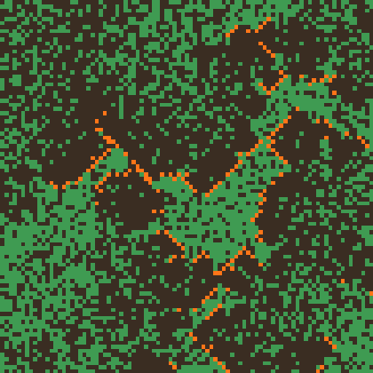

t

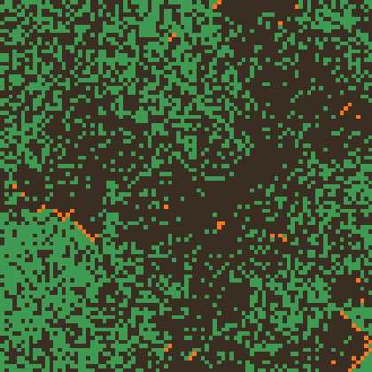

t + 10

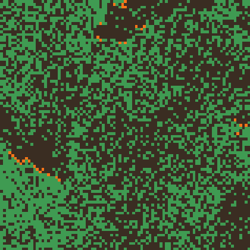

t + 20

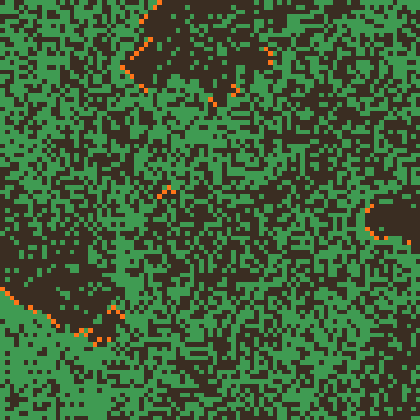

t + 30

06

## What emerges

### A density that holds itself steady

Forest density over 1500 steps at `f/p = 0.001`. It wanders but never drifts: fires cut it back exactly as fast as growth builds it up. No parameter was tuned to make this happen — that is the *self-organised* part.

### Fires with no typical size

When lightning strikes a tree, the whole connected patch it belongs to burns. So the sizes of fires are the sizes of forest patches — and those follow a power law, `N(s) ∝ s−τ`, close to straight over three decades on log axes.

Number of forest clusters of size `s`, log-binned, both axes logarithmic. The dashed guide has slope −2, the exponent `τ = 2` the paper derives for two dimensions. A straight line here means there is no characteristic fire size: the same rules produce a fire of ten trees and a fire of five thousand.

Where this demo departs from the paper

Drossel and Schwabl report a mean density of **0.39**; this lattice settles near **0.44**. Two honest reasons: `f/p = 0.001` is not the `f/p → 0` limit the theory assumes, and at 200 × 200 the largest fires run into the edge of the map. The paper is explicit that the lattice must be much larger than the biggest forest cluster. Shrink `f/p`, grow the lattice, and the number falls towards 0.39.

07

## Run it yourself

Everything on this page comes from three R scripts and one package.

| File | What it does |
| --- | --- |
| `R/forest_fire.R` | The model: `ff_init()`, `ff_step()`, `ff_simulate()` |
| `R/animate.R` | Runs 400 steps and writes the animated GIF |
| `R/figures.R` | Maps and statistics for this page |
| `html/build.py` | Inlines those assets into a single HTML file |

Terminal

```bash
install.packages("gifski")   # once, from an R session

Rscript R/animate.R          # output/forest_fire.gif
Rscript R/figures.R          # output/figures/
python html/build.py         # output/tutorial.html
```

### Try changing something

The fastest way to understand a model is to break it. A few edits worth making in `R/forest_fire.R`:

| Change | What you should see |
| --- | --- |
| `periodic = TRUE` | Fire wraps around the edges; no more boundary where fires go to die |
| Add the diagonal neighbours | Fire spreads more easily, forest density drops |
| Make `p` vary in space | Productivity gradients — fires stall in the slow-growing half |
| Give burning cells two steps | Fires that smoulder; fronts become thicker bands |

The wrapper below runs the model without any plotting, and hands back the density series plus the final lattice — a good starting point for your own analysis.

R/forest_fire.R — ff_simulate()

```r
ff_simulate <- function(steps, size = 200L, p = 0.02, f = 2e-5,
                        periodic = FALSE, state = NULL) {
  if (is.null(state)) state <- ff_init(size)

  out <- data.frame(
    step    = seq_len(steps),
    trees   = NA_real_,
    burning = NA_real_
  )

  for (i in seq_len(steps)) {
    state <- ff_step(state, p = p, f = f, periodic = periodic)
    out$trees[i]   <- mean(state == TREE)
    out$burning[i] <- mean(state == BURNING)
  }

  attr(out, "final_state") <- state
  out
}
```

Drossel, B. & Schwabl, F. (1992). Self-Organized Critical Forest-Fire Model.  
*Physical Review Letters* **69**(11), 1629–1632.